# Water Levels

R. G. Cronce

July 24, 2019

## Water Levels from USGS

The original Web article was about a location in PA that showed data for rainfall, water flow, and many other variables at a resolution of 30 minutes. The story was on Rbloggers with the link to the original article given as: [Original Web Article](https://rclimate.wordpress.com/2019/07/19/analysis-of-a-flash-flood/)

This article contains a [Link to the Data](https://waterdata.usgs.gov/nwis/uv?site_no=01474500) that gives a number of different measurements including temperature, precipitation, water flow rates, and water gage height. This is interesting since it allows you to visualize/model the relationship between precipitation and flooding.

Trying to get a little closer to home I looked at the Waukesha Fox river measurements. All that is available here is water flow.

Not sure what I can do with this but the data link is shown below for the US Geological Survey. They have *continuous* data on many locations starting in 1963 to the present. The particular link below points was Waukesha but you can navigate up and find a map to select other sites. The particular data available is site-specific. I wanted to look at precipitation and see how it relates to flow rates but I can’t do that using just this data for the Fox river:

[Website for USGS Water Data - Fox River](https://waterdata.usgs.gov/nwis/inventory?agency_code=USGS&site_no=05543830)

There is a link on the USGS page to provide more information about flooding where the gage level is shown. I haven’t investigated this data in detail, yet:

[NWS Flood Data](https://water.weather.gov/ahps2/hydrograph.php?wfo=mkx&gage=wkew3&view=1,1,1,1,1,1)

A brief look shows that gage height and flow rates at 15 minute intervals for the past 10 days. I could not find any older data. There are a large number of links from this page that might have more data. It might also be interesting to look at geographically adjacent areas and try to plot the levels versus time as a 3D surface map (e.g. see the surface flow of water during a storm).

This is all in the very early stages of investigation.

```r
d=read.delim("all_data.txt",comment.char="#")
head(d)
```

```
##   agency_cd  site_no   datetime X155309_00060_00003 X155309_00060_00003_cd
## 1        5s      15s        20d                 14n                    10s
## 2      USGS 05543830 1963-01-01                7.00                      A
## 3      USGS 05543830 1963-01-02                7.00                      A
## 4      USGS 05543830 1963-01-03                7.00                      A
## 5      USGS 05543830 1963-01-04                7.00                      A
## 6      USGS 05543830 1963-01-05                7.00                      A
```

Clean up the data. The first row of the file is some sort of format specification that we will ignore. The columns are names based on some codes from USGS.

```r
d2=d[-1,]
cc=names(d2)
cc[4]="Flow"
cc[5]="Status"
names(d2)<-cc
d2[d2$Flow=="Ice",]<-NA
d2$Flow<-as.numeric(as.character(d2$Flow))
d2$datetime<-as.Date(as.character(d2$datetime))
head(d2)
```

```
##   agency_cd  site_no   datetime Flow Status
## 2      USGS 05543830 1963-01-01    7      A
## 3      USGS 05543830 1963-01-02    7      A
## 4      USGS 05543830 1963-01-03    7      A
## 5      USGS 05543830 1963-01-04    7      A
## 6      USGS 05543830 1963-01-05    7      A
## 7      USGS 05543830 1963-01-06    8      A
```

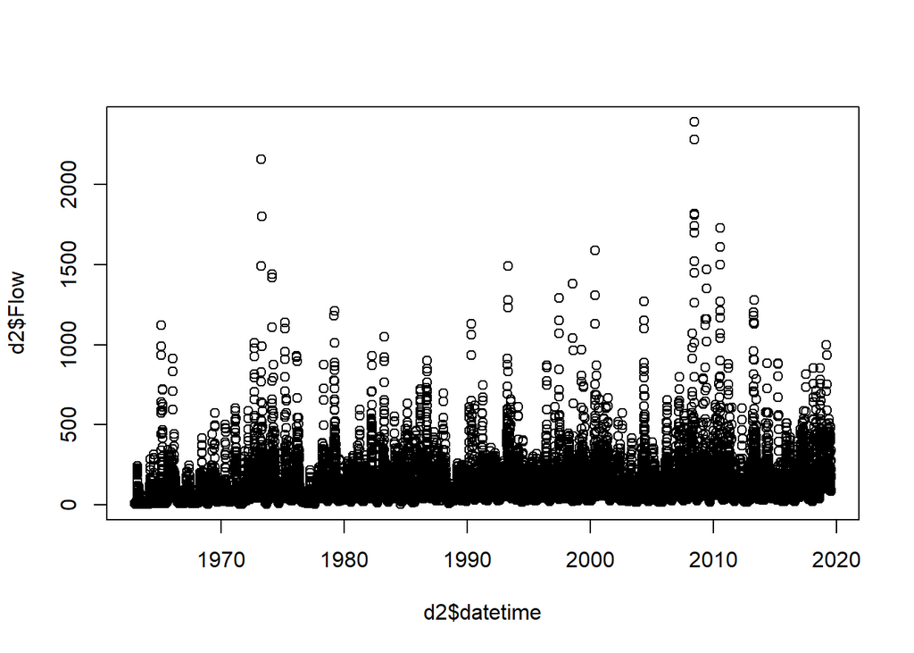

```r
plot(d2$datetime,d2$Flow)
```

It is difficult to make too many conclusions from this data. It seems like the flow rate may be increasing over time but it is uncertain.

Looking at the mean flow rate per year might be more revealing.

```r
d2$y=format(d2$datetime,"%Y")
head(d2)
```

```
##   agency_cd  site_no   datetime Flow Status    y
## 2      USGS 05543830 1963-01-01    7      A 1963
## 3      USGS 05543830 1963-01-02    7      A 1963
## 4      USGS 05543830 1963-01-03    7      A 1963
## 5      USGS 05543830 1963-01-04    7      A 1963
## 6      USGS 05543830 1963-01-05    7      A 1963
## 7      USGS 05543830 1963-01-06    8      A 1963
```

```r
d3=aggregate(Flow~y,d2,mean)
head(d3)
```

```
##      y      Flow
## 1 1963  23.09096
## 2 1964  33.19208
## 3 1965 113.53863
## 4 1966  68.81945
## 5 1967  39.46493
## 6 1968  52.43962
```

```r
d3$y=as.numeric(d3$y)
m=lm(Flow~y,d3)
summary(m)
```

```
##
## Call:
## lm(formula = Flow ~ y, data = d3)
##
## Residuals:
##     Min      1Q  Median      3Q     Max
## -73.414 -33.272  -1.168  20.116 112.860
##
## Coefficients:
##               Estimate Std. Error t value Pr(>|t|)
## (Intercept) -3056.4153   610.4687  -5.007 6.05e-06 ***
## y               1.5941     0.3066   5.199 3.03e-06 ***
## ---
## Signif. codes:  0 '***' 0.001 '**' 0.01 '*' 0.05 '.' 0.1 ' ' 1
##
## Residual standard error: 38.08 on 55 degrees of freedom
## Multiple R-squared:  0.3295, Adjusted R-squared:  0.3173
## F-statistic: 27.03 on 1 and 55 DF,  p-value: 3.033e-06
```

```r
confint(m)
```

```
##                     2.5 %       97.5 %
## (Intercept) -4279.8218898 -1833.008667
## y               0.9796701     2.208565
```

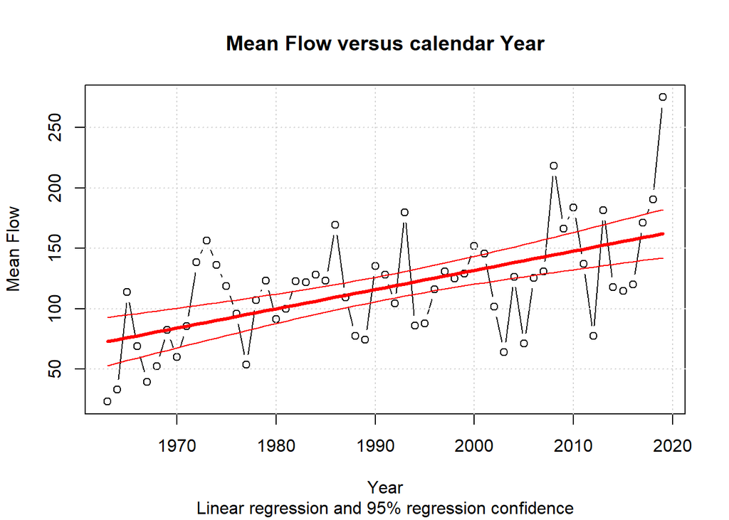

```r
zzz=predict(m,d3,interval="confidence")
d3=cbind(d3,zzz)
plot(d3$y,d3$Flow,type='b',
     xlab="Year",
     ylab="Mean Flow",
     ylim=range(d3[,-1]))
grid()
lines(d3$y,d3$fit,col="red",lwd=3)
lines(d3$y,d3$lwr,col="red",lwd=1)
lines(d3$y,d3$upr,col="red",lwd=1)
title(main="Mean Flow versus calendar Year",
      sub="Linear regression and 95% regression confidence")
```

From this it appears that flow rate is increasing over time.

Why?